# git basics

vgranda

2023-01-19

## Introduction

`git` is a version control software, not the only one, but one of the most widely used. But, what is *version control*?  
As the [git book](https://git-scm.com/book/en/v2) explains, version control systems allow to record the changes a file or a set of files have been through, allowing to revert files to a previous state, compare changes over time…  
Version control systems, and `git` in particular, are designed with collaborative development in mind (a team working in the same codebase), but it doesn’t mean it can’t be used in *solo* projects, and in fact, is recommended.

> **Important!! `git` is not a backup system**. Is not intended to be a backup system. Think of it more as a time machine for your code, but you should have backup copies besides any version control system.

## How `git` works

Think of `git` as a series of snapshots of the files. Every time we `commit` some changes, an image of the state of the files is stored. This allows to follow the development of the project (how things changed), but more importantly, it allows to go back to any point in the `commit` history.

Let’s say that you are performing some analyses in your R project and something is not working as intended. You try to fix it, but at the end you have made so many changes to the analysis code that is impossible to revert to the state in which everything worked again. With `git` you have the history of changes stored, you can see differences in files you modified, and when you modified it, and also you can go back easily to any point in that history.

## What is GitHub

GitHub is an online service that allows to have a remote copy of your `git` repository, making easier synchronising between computers. With GitHub, you always have an online resource with your work that can be pulled at any time from any computer you have access. More on this later.

## Basic `git` usage

The `git` workflow is as follows:

1. You make changes
2. You `add` and `commit` those changes to `git` history
3. You `push` your changes to GitHub

If you are developing in two different machines, then GitHub acts as a middleman for you to be able to get the latest changes you made:

1. You make changes
2. You `add` and `commit` those changes to `git` history
3. You `push` your changes to GitHub
4. You go on remote work, with your laptop
5. You `pull` the repository from GitHub
6. You make changes
7. You `add` and `commit` those changes to `git` history
8. You `push` your changes to GitHub
9. You go back to the office, with your work computer
10. You `pull` the repository from GitHub
11. You make changes
12. You `add` and `commit` those changes to `git` history
13. You `push` your changes to GitHub

## Working with `git` and GitHub

### Creating a GitHub account

If you don’t have a GitHub account yet, go to github.com and follow the page instructions to create a new account.

> Important! It’s recommended to create the GitHub account with a personal mail. Institutional mail addresses come and go, but this way you will be able to access GitHub even if you change institutions/companies

### Installing `git`

In Windows, go to https://git-scm.com/download/win and the download will start automatically. If not, just click the download link.

In Mac, check at https://git-scm.com/download/mac if is not installed already.

In linux, check your package manager (`dnf`, `apt`, `pacman`…) for the package available for your distribution.

#### Configuring git for our user

After installing `git` and having a GitHub account, we can configure our `git` installation with our username and mail, that way when we `push` (more on this later) to GitHub things will be easier to identify the author of the `commit`. For configuring `git` with our user, we just write in the terminal the following commands:

```
git config --global user.name "MyUser"
git config --global user.email "my@mail.com"
```

### Starting a git repository

#### Command line

In the terminal, at the folder we want to convert to a `git` repository we can write

```
git init
```

And it will become a version controlled folder.

#### RStudio project

From RStudio, at the moment of creating a new project we need to check the corresponding checkbox:

[figure not shown]

If you have already created the project without `git`, you can always go to the project options (`Tools` menu -> `Project Options...`) and select `git` in the Git/SVN menu:

[figure not shown]

## Using `git` like a pro

### Making changes

> If you have a project already created with files (scripts, data…) that you just want to start using `git` with, you can go directly to the `commit` step and follow from there.

Let’s create a file in our repository, called `my_script.R` with some boilerplate code and save it:

```r
# calculate flower area index index
library(dplyr)
iris %>%
  mutate(FAI = Sepal.Length * Petal.Length)
```

If we go to the *git* tab in RStudio we can see something has changed. `my_script.R` appears now with unknown status. This means that a new file has appeared in the repository (our script) but `git` doesn’t know yet what to do with it:

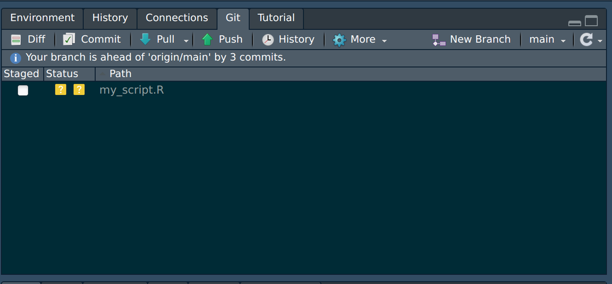

### Adding new files to `git`

In the git tab in RStudio, we can check the `my_script.R` file checkbox, which tells `git` to `add` the file to the repository and start registering any change for that file:

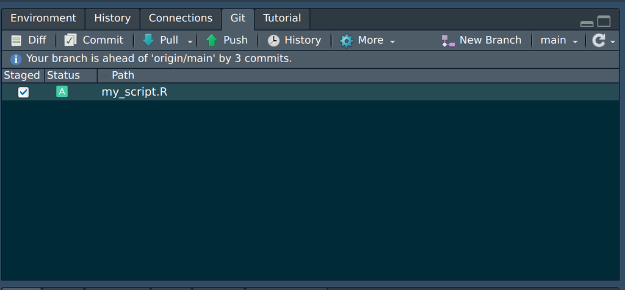

We can see that now the status has changed to `added` (bluish green A). We can do this for all the files we want to monitor at the same time.

If we prefer to use the terminal, we can add files with `git add`:

```
git add my_script.R
```

### `commit` the changes

To create a snapshot of the state of the files in any moment, we `commit` the changes after `add`ing them. In the git tab of RStudio we click the `Commit` button. This opens a windows in which we can write a `commit` description (the text that explains what the changes are about). This text should be descriptive of the changes we made, *i.e.* “my_script added, making some flower indexes” is better than “some code”:

[figure not shown]

Now we have the changes recorded in our local git repository. We can continue making changes and `commit`ing them to the repository (adding more code to `my_script.R`, creating other scripts, saving plots, adding data…).

#### Good practices with `commit`s

1. Every `commit` should have a description short but informative of the changes made.
2. `commit`s should be focused in specific changes. Big `commit`s that change multiple files, in multiple locations, affecting different analyses… should be avoided.

## Creating the GitHub repository

To be able to use GitHub with our local `git` repository, we need to create a *remote* repository in GitHub. For that, we just click in the `New` button in our GitHub profile:

[figure not shown]

This will lead us to a page in which we indicate the name of the repository (the same as our project in RStudio) and without anything else, we click in `Create repository` button:

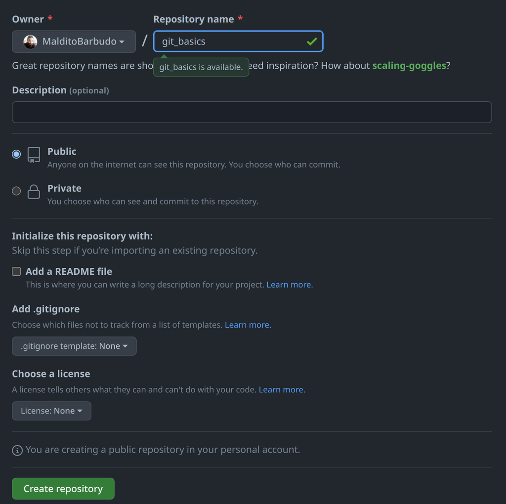

With the GitHub repository created, some instructions appear, we will follow the ones under `…or push an existing repository from the command line`. We can copy the commands in that section and paste them to the terminal to link our local repository with the GitHub repository:

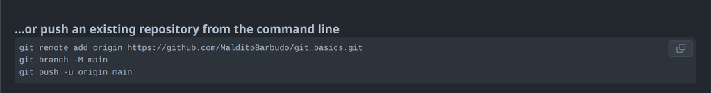

Doing this will result in our local repository linked with the GitHub remote one:

```
> git remote add origin https://github.com/MalditoBarbudo/git_basics.git
> git branch -M main
> git push -u origin main

Username for 'https://github.com': MalditoBarbudo
Password for 'https://MalditoBarbudo@github.com':

Enumerating objects: 22, done.
Counting objects: 100% (22/22), done.
Delta compression using up to 8 threads
Compressing objects: 100% (21/21), done.
Writing objects: 100% (22/22), 315.97 KiB | 9.87 MiB/s, done.
Total 22 (delta 8), reused 0 (delta 0), pack-reused 0
remote: Resolving deltas: 100% (8/8), done.
To https://github.com/MalditoBarbudo/git_basics.git
 * [new branch]      main -> main
branch 'main' set up to track 'origin/main'.
```

And our local contents will be already present in the GitHub repository page:

[figure not shown]